# Age pyramids

## `ggplot()`

Using `ggplot()` to build your age pyramid allows more flexibility, but requires more effort and understanding of how `ggplot()` works.

### Constructing the plot

The first thing to understand is that initially the age groups are on the x-axis. You are creating a `geom_histogram()` layer for each of the two genders, **one in positive count values and the other in negative count values**. Then you are using the `coord_flip()` command to switch the X and Y axes.

TODO - automate the axis limits…

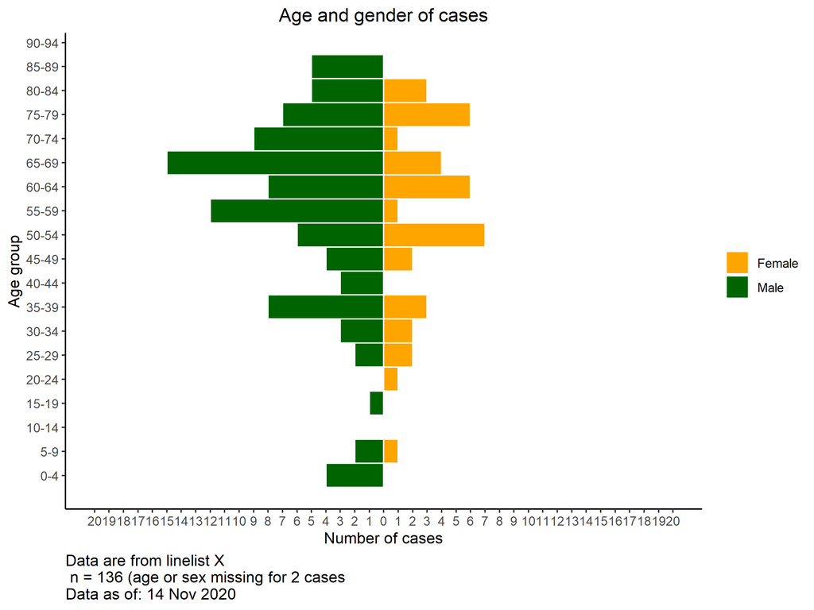

```r
## make the actual plot
age_sex_pyramid <- linelist %>%
  ggplot(aes(x = age, fill = gender)) +
  geom_histogram(data = filter(linelist, gender == "f"),
                 breaks = age_seq,
                 colour = "white",
                 closed = "left") +
  geom_histogram(data = filter(linelist, gender == "m"),
                 breaks = age_seq,
                 aes(y=..count..*(-1)),
                 color = "white",
                 closed = "left") +
  scale_x_continuous(breaks = age_seq + 2.5, labels = age_lab, limits = c(0, 90)) +
  scale_y_continuous(limits = c(-20, 20), breaks = seq(-20,20,1), labels = abs(seq(-20, 20, 1))) +
  scale_fill_manual(
    values = c("f" = "orange",
               "m" = "darkgreen"),
    labels = c("Female", "Male"),
  ) +
  labs(
    x = "Age group",
    y = "Number of cases",
    fill = NULL,
    caption = glue::glue("Data are from linelist X \n n = {nrow(linelist)} (age or sex missing for {sum(is.na(linelist$gender) | is.na(linelist$age))} cases \nData as of: {format(Sys.Date(), '%d %b %Y')}")) +
  coord_flip() +
  theme(
    panel.grid.major = element_blank(),
    panel.grid.minor = element_blank(),
    panel.background = element_blank(),
    axis.line = element_line(colour = "black"),
    plot.title = element_text(hjust = 0.5),
    plot.caption = element_text(hjust=0, size=11)) +

  ggtitle(paste0("Age and gender of cases"))

print(age_sex_pyramid)
```

### Compare to expected demographics

With the flexibility of `ggplot()`, you can have a second layer of bars in the background that represent the true population pyramid. This can provide a nice visualization to compare the observed counts with the baseline.

```r
# TO DO

# extract population data
pop <- rio::import(here::here("data/RDC_population_polio_2020.xls")) %>%
  mutate_if(is.character, tolower)
```